# HW02: Practice with logistic regression and decision tree

[Please put your name and NetID here.]

Name: Jiapeng Wang

NetID: jwang2928

## Hello Students:

- Start by downloading HW02.ipynb from this folder. Then develop it into your solution.
- Write code where you see "... your code here ..." below. (You are welcome to use more than one cell.)
- If you have questions, please ask them in class, office hours, or piazza. Our TA and I are very happy to help with the programming (provided you start early enough, and provided we are not helping so much that we undermine your learning).
- When you are done, run these Notebook commands:
  - Shift-L (once, so that line numbers are visible)
  - Kernel > Restart and Run All (run all cells from scratch)
  - Esc S (save)
  - File > Download as > HTML
- Turn in:
  - HW02.ipynb to Canvas's HW02.ipynb assignment
  - HW02.html to Canvas's HW02.html assignment
  - As a check, download your files from Canvas to a new 'junk' folder. Try 'Kernel > Restart and Run All' on the '.ipynb' file to make sure it works. Glance through the '.html' file.
- Turn in partial solutions to Canvas before the deadline. e.g. Turn in part 1, then parts 1 and 2, then your whole solution. That way we can award partial credit even if you miss the deadline. We will grade your last submission before the deadline.

```python
# ... your code here ... (import statements)
import numpy as np
import pandas as pd
import matplotlib.pyplot as plt

from sklearn import linear_model
from sklearn.tree import DecisionTreeClassifier, DecisionTreeRegressor
from sklearn import tree # for tree.plot_tree()
from sklearn.tree import export_text # for export_text()

import warnings
warnings.filterwarnings('ignore')
```

# 1. Logistic regression

# 1a. Make a logistic regression model

relating the probability an iris has Species='virginica' to its 'Petal.Length' and classifying irises as 'virginica' or not 'virginica' (i.e. 'versicolor').

- Read http://www.stat.wisc.edu/~jgillett/451/data/iris.csv into a DataFrame.
- Make a second data frame that excludes the 'setosa' rows (leaving the 'virginica' and 'versicolor' rows) and includes only the Petal.Length and Species columns.
- Use `linear_model.LogisticRegression(C=1000)` so we all get the same results (they vary with `C`).
- Train the model using $X=$ petal length and $y=$ whether the Species is 'virginica'. (I used "y = (df['Species'] == 'virginica').to_numpy().astype(int)", which sets y to zeros and ones.)
- Report its accuracy on the training data.
- Report the estimated P(Species=virginica | Petal.Length=5).
- Report the predicited Species ('virginica' or 'versicolor') for Petal.Length=5.
- Make a plot showing:
  - the data points
  - the estimated logistic curve
  - and what I have called the "sample proportion" of y == 1 at each unique Petal.Length value
  - a legend and title and other labels necessary to make the plot easy to read

```python
# ... your code here ...
df = pd.read_csv('http://www.stat.wisc.edu/~jgillett/451/data/iris.csv')
df_2 = df[df['Species'] != 'setosa'][['Petal.Length', 'Species']]
clf = linear_model.LogisticRegression(C=1000)
X = df_2[['Petal.Length']]
y = (df_2['Species'] == 'virginica').to_numpy().astype(int)
```

```python
clf.fit(X, y)
print(f'the accuracy on the training data is {clf.score(X, y)}')
prob_virginica = clf.predict_proba([[5]])[0, 1]
print(f"Estimated P(Species=virginica | Petal.Length=5): {prob_virginica:.3}")
print(f'clf.predict([[5]]) = 1, which means the predicited Species for Petal.Length=5 is virginica')
```

```
the accuracy on the training data is 0.93
Estimated P(Species=virginica | Petal.Length=5): 0.773
clf.predict([[5]]) = 1, which means the predicited Species for Petal.Length=5 is virginica
```

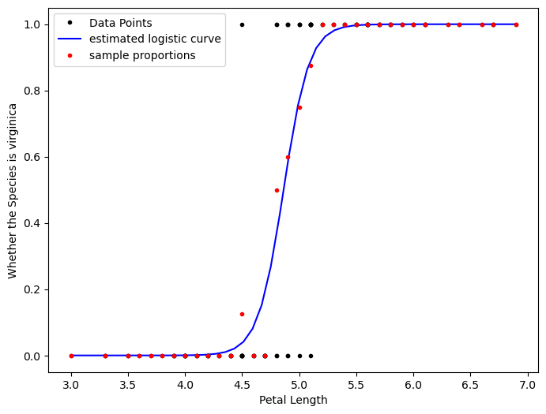

```python
plt.figure(figsize=(8, 6))
plt.plot(X, y, '.', color='black', label='Data Points')
plt.xlabel('Petal Length')
plt.ylabel('Whether the Species is virginica')
xplot = np.linspace(start=X.min(), stop=X.max())
yplot = clf.predict_proba(xplot.reshape(-1, 1))[:, 1]
plt.plot(xplot, yplot, color='blue', label='estimated logistic curve')
x_values, x_counts = np.unique(X, return_counts=True)
n_x_values = x_values.shape[0]
success_proportion_per_x_value = np.zeros(n_x_values)
for i in np.arange(n_x_values):
    success_proportion_per_x_value[i] = np.sum(y[df_2['Petal.Length'] == x_values[i]]) / x_counts[i]
plt.plot(x_values, success_proportion_per_x_value, '.', color='red',
         label='sample proportions')
plt.legend()
plt.show()
```

## 1b. Do some work with logistic regression by hand.

Consider the logistic regression model, $P(y _i = 1) = \frac{1}{1 + e^{-(\mathbf{w x} + b)}}\,.$

Logistic regression is named after the log-odds of success, $\ln \frac{p}{1 - p}$, where $p = P(y_i = 1)$. Show that this log-odds equals $\mathbf{w x} + b$. (That is, start with $\ln \frac{p}{1 - p}$ and connect it in a series of equalities to $\mathbf{w x} + b$.)

#### ... your Latex math in a Markdown cell here ...

$\begin{align*} % In this Latex context, "&" separates columns and "\\" ends a line. \ln \frac{p}{1 - p} & = \ln \frac{1}{e^{-(\mathbf{w x} + b)}} \\ & = -\ln(e^{-(\mathbf{w x} + b)})\\ & = \mathbf{w x} + b\\ \end{align*} $

### 1c. Do some more work with logistic regression by hand.

I ran some Python/scikit-learn code to make the model pictured here:

[figure not shown]

From the image and without the help of running code, match each code line from the top list with its output from the bottom list.

1. `model.intercept_`
2. `model.coef_`
3. `model.predict(X)`
4. `model.predict_proba(X)[:, 1]`

A. `array([0, 0, 0, 1])`, B. `array([0.003, 0.5, 0.5, 0.997])`, C. `array([5.832])`, D. `array([0.])`

1: D, 2: C, 3: A, 4: B

# 2. Decision tree

## 2a. Make a decision tree model on a Titanic data set.

Read the data from http://www.stat.wisc.edu/~jgillett/451/data/kaggle_titanic_train.csv.

These data are described at https://www.kaggle.com/competitions/titanic/data (click on the small down-arrow to see the "Data Dictionary"), which is where they are from.

- Retain only the Survived, Pclass, Sex, and Age columns.
- Display the first seven rows (passengers). Notice that the Age column includes NaN, indicating a missing value.
- Drop rows with missing data via `df.dropna()`. Display your data frame's shape before and after dropping rows. (It should be (714, 4) after dropping rows.)
- Add a column called 'Female' that indicates whether a passenger is Female. You can make this column via `df.Sex == 'female'`. This gives bool values True and False, which are interpreted as 1 and 0 when used in an arithmetic context.
- Train a decision tree with `max_depth=None` to decided whether a passenger `Survived` from the other three columns. Report its accuracy (with 3 decimal places) on training data along with the tree's depth (which is available in `clf.tree_.max_depth`).
- Train another tree with `max_depth=2`. Report its accuracy (with 3 decimal places). Use `tree.plot_tree()` to display it, including feature_names to make the tree easy to read.

```python
# ... your code here ...
Tianic = pd.read_csv('http://www.stat.wisc.edu/~jgillett/451/data/kaggle_titanic_train.csv')
df = Tianic[['Survived', 'Pclass', 'Sex', 'Age']]
print(df.head(7))
```

```
   Survived  Pclass     Sex   Age
0         0       3    male  22.0
1         1       1  female  38.0
2         1       3  female  26.0
3         1       1  female  35.0
4         0       3    male  35.0
5         0       3    male   NaN
6         0       1    male  54.0
```

```python
print(f'Before dropping rows with missing data the shape is {df.shape}')
df = df.dropna()
print(f'After dropping rows with missing data the shape is {df.shape}')
```

```
Before dropping rows with missing data the shape is (891, 4)
After dropping rows with missing data the shape is (714, 4)
```

```python
df['Female'] = (df.Sex == 'female').astype(int)
clf = DecisionTreeClassifier(max_depth=None)
X = df[['Pclass', 'Female', 'Age']]
y = df['Survived']
clf.fit(X, y)
print(f'Accuracy on training data is {clf.score(X, y):.3}.')
print(f'The depth of the tree is {clf.tree_.max_depth}.')
```

```
Accuracy on training data is 0.896.
The depth of the tree is 15.
```

```python
clf_2 = DecisionTreeClassifier(max_depth=2)
clf_2.fit(X, y)
print(f'Accuracy on training data for another tree with max_depth=2 is {clf_2.score(X, y):.3}.')
```

```
Accuracy on training data for another tree with max_depth=2 is 0.803.
```

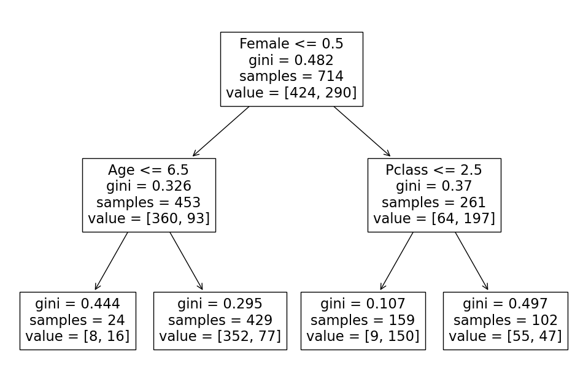

```python
fig = plt.figure(figsize=(12, 8))
_ = tree.plot_tree(clf_2, feature_names=X.columns)
```

## 2b. Which features are used in the (max_depth=2) decision-making? Answer in a markdown cell.

'Pclass', 'Female', 'Age'

## 2c. What proportion (in the cleaned-up data) of females survived? What proportion of males survived?

Answer in two sentences via print(), with each proportion rounded to three decimal places.

Hint: There are many ways to do this. One quick way is to find the average of the `Survived` column for each subset.

```python
# ... your code here ...
proportion_females = df[df['Female'] == 1]['Survived'].mean()
proportion_males = df[df['Female'] == 0]['Survived'].mean()
print(f'Proportion of females who survived: {proportion_females:.3}')
print(f'Proportion of males who survived: {proportion_males:.3}')
```

```
Proportion of females who survived: 0.755
Proportion of males who survived: 0.205
```

## 2d. Do some decision tree calculations by hand.

Consider a decision tree node containing the following set of examples $S = \{(\mathbf{x}, y)\}$ where $\mathbf{x} = (x_1, x_2)$:

((4, 9), 1)

((2, 6), 0)

((5, 7), 0)

((3, 8), 1)

Find the entropy of $S$.

$\begin{align*} -(\frac{2}{4}) \log_2(\frac{2}{4}) = -(\frac{1}{2}) \log_2(\frac{1}{2}) = -(\frac{1}{2}) (-1) = \frac{1}{2} \end{align*}$

Then we get the entropy of S,

$ \text{Entropy}(S) = \sum_{i=1}^{n} P(x_i) [-\log_2 P(x_i)] = \frac{1}{2} + \frac{1}{2} = 1 $

## 2e. Do some more decision tree calculations by hand.

Find a (feature, threshold) pair that yields the best split for this node.

when $j$ = 1, $t$ = 2

$\begin{align*} H(S_-, S_+) = \frac{|S_-|}{|S|} \cdot H(S_-) + \frac{|S_+|}{|S|} \cdot H(S_+) = \frac{1}{4} \cdot 0 + \frac{3}{4} \cdot (\log_2(3) - \frac{2}{3}) \end{align*}$

Repeat the process, we get that when $j$ = 2, $t$ = 7, the weighted average entropy reach the minimum.

Thus, the pair(feature=$x_2$, threshold=7) yields the best split for this node.